# Point Estimation of Population Statistics

Author & Instructor: Diana NURBAKOVA, PhD.

```python
%%html
<link rel="stylesheet" type="text/css" href="../styles/styles.css">
```

## Learning Objectives

By the end of this lesson, you will be able to:

- Define and distinguish point estimators
- Evaluate estimator properties (bias, variance, MSE)
- Derive MLE for standard distributions

```python
import numpy as np
import pandas as pd
import matplotlib.pyplot as plt
import seaborn as sns
from scipy import stats
from mpl_toolkits.mplot3d import Axes3D
import warnings
warnings.filterwarnings('ignore')

# Set style for better-looking plots
plt.style.use('seaborn-v0_8-darkgrid')
sns.set_style("whitegrid")
#sns.set_palette("husl")

# Set random seed for reproducibility
np.random.seed(42)
```

```python
from ipywidgets import interact, IntSlider, FloatSlider, Dropdown
import ipywidgets as widgets
```

```python
plt.rcParams['font.family'] = ['DejaVu Sans', 'Segoe UI Emoji']
```

```python
import sys
from pathlib import Path

# Add the "resources" directory to the path
project_root = Path().resolve().parent.parent
resources_path = project_root / 'resources'
sys.path.insert(0, str(resources_path))
```

```python
from estimators import (generate_hook_data, explore_sampling_distribution, demonstrate_estimator_concept, visualize_bias_variance_tradeoff, plot_heads_tails,
                        demonstrate_likelihood_concept, plot_binomial, demonstrate_prior_importance, compare_mle_map)
```

#### 🎯 Today's Challenge: The Neural Network Initialization Mystery

You're training a neural network for image classification. A critical hyperparameter is the weight initialization scale $\sigma$.

- Too small → vanishing gradients, slow learning
- Too large → exploding gradients, instability
- Just right → optimal convergence

By the end of today: You'll have a mathematical framework to answer all these questions with confidence.

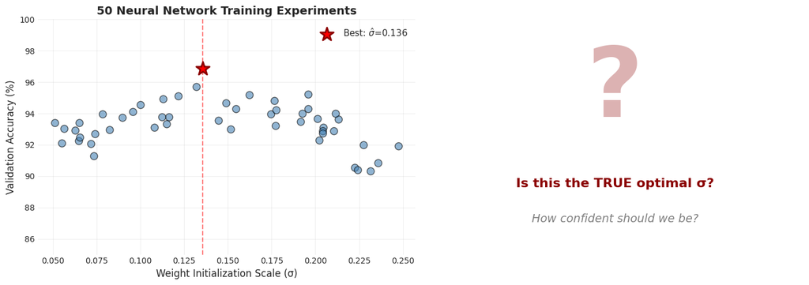

```python
# visualisation
generate_hook_data()
```

## What is a Statistic?

#### Definition: Statistic

A **statistic** is any function of the sample data that doesn't depend on unknown parameters.

If $X_1, X_2, ..., X_n$ is a random sample, then $T(X_1, X_2, ..., X_n)$ is a statistic.

*Examples of Statistics:*

- Sample mean: $\bar{X} = (1/n)\sum_i^n X_i$
- Sample variance: $s^2 = (1/(n-1))\sum_i^n(X_i - \bar{X})^2$
- Sample median: middle value when data is sorted
- Sample maximum: $max(X_1, ..., X_n)$
- Sample range: $max(X_i) - min(X_i)$

*Not statistics (depend on unknown parameters)*:

- $(\hat{X} - \mu)/\sigma$ where $\mu, \sigma$ are unknown
- $P(X > \theta)$ where $\theta$ is unknown

### Two Types of Statistics for Estimation

|  | Point Statistic (Point Estimator) | Interval (Range) Statistic (Interval Estimator) |
| --- | --- | --- |
| **Definition** | A **single number** that estimates the parameter | A **range of plausible values** for the parameter |
| **Notation** | $\hat{\theta}$ (theta-hat) represents a point estimate of $\theta$ | interval containing the point estimate and the margin of error, e.g. $\mu ± E$ where $E$ is a margin of error |
| **Characteristics:** | - Simple, easy to interpret- No information about uncertainty- "Best guess" at the true value | - Provides range of uncertainty- Comes with confidence level (e.g., 95%)- More informative than point estimate- Accounts for sampling variability |
| **Interpretation** |  | *"We are 95% confident that the true parameter lies in this interval"* |
| **Examples** | - Estimating population mean $\mu$: use $\bar{X} = 94.3$- Estimating population variance $\sigma^2$: use $s^2 = 15.7$- Estimating success probability $p$: use $\hat{p} = 0.65$ | - Estimating $\mu$: [92.1, 96.5] (95% confidence interval)- Estimating $\sigma^2$: [12.3, 21.4]- Estimating $p$: [0.58, 0.72] |
| **Use in ML** | - Model parameters (weights, biases)- Performance metrics (accuracy = 0.87)- Quick decision-making | - Model comparison: "Is model A really better than B?"- Performance ranges: accuracy $\in$ [0.84, 0.90]- Risk assessment- Communicating uncertainty to stakeholders |

## What is an Estimate?

#### Definition: Estimator

An **estimator** is a rule (function) that takes data and produces an estimate of an unknown parameter.

**Notation:**

- $\theta$ = true (unknown) parameter
- $X_1, X_2, ..., X_n$ = observed data (random sample)
- $\hat{\theta} = \hat{\theta}(X_1, ..., X_n)$ = estimator (a function of the data)

**Key insight:** An estimator is itself a random variable (because it depends on random data)

Let's consider the darts analogy for a better understanding estimators.

Imagine throwing darts at a target. The **bullseye** represents the **true parameter value** $\theta$, and each **dart** represents an **estimate** $\hat{\theta}$ from a different sample.

We simulate the same estimation process many times (like throwing many darts), each time with a different random sample. This shows us the **sampling distribution** of our estimator—how the estimates vary from sample to sample.

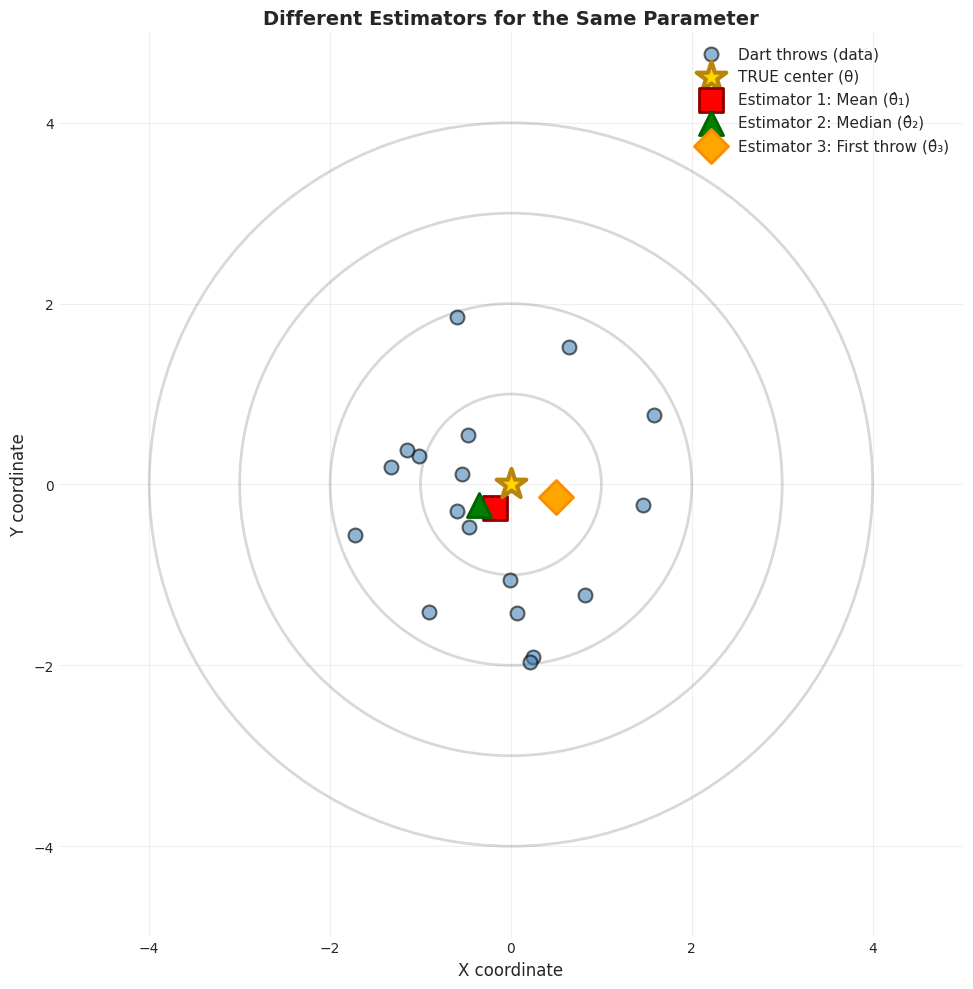

```python
# darts analogy
demonstrate_estimator_concept()
```

#### 🤖 ML Application Spotlight: Where Do We Use Estimators?

Everywhere in machine learning:

- Neural Networks: Estimating optimal weights from training data
- Clustering: Estimating cluster centers (k-means uses sample means)
- Gaussian Mixture Models: Estimating $\mu$ and $\sigma$ for each component
- Reinforcement Learning: Estimating value functions from rewards
- Generative Models: Estimating distribution parameters (GANs, VAEs)

The fundamental question: Given data, what's our best guess for the model parameters?

Let's consider the following setup.

We repeatedly:

1. Draw a random sample of size $n$ from a population
2. Compute an estimate $\hat{\theta}$ from that sample
3. Plot the estimate as a point
4. Build up a histogram of all estimates

For the sake of comparison, we will use the true values of the distribution parameters (e.g. true $\mu = 5$ and $\sigma = 2$).

As we increase the number of samples:

1. Distribution Shape Emerges
   - Initially: just a few scattered points
   - Eventually: a clear bell-shaped curve (often normal by CLT)
   - The shape tells us about the estimator's behavior
2. Center (Bias)
   - Where is the histogram centered?
   - If centered on the green line (true $\theta$): **unbiased**
   - If shifted left or right: **biased**
3. Spread (Variance)
   - How wide is the histogram?
   - Narrow spread: **low variance** (precise)
   - Wide spread: **high variance** (imprecise)
4. Convergence
   - With more samples, the histogram stabilizes
   - This demonstrates the Law of Large Numbers
   - The empirical distribution → theoretical distribution

Parameters to explore:

1. Sample Size (n):
- Small n → wider sampling distribution (more uncertainty)
- Large n → narrower sampling distribution (less uncertainty)
- This is why "more data is better"
2. Number of Samples:
- More samples → smoother histogram
- Shows the sampling distribution more clearly
- In practice, we only get ONE sample, but this helps us understand uncertainty
3. Different Estimators:
- Compare sample mean vs. sample median
- See which has lower variance
- Understand when each is preferable

```python
# interactive exploration of sampling distribution
interact(explore_sampling_distribution,
         true_mean=FloatSlider(min=0, max=10, step=0.5, value=5, description='True μ:'),
         true_std=FloatSlider(min=0.5, max=5, step=0.5, value=2, description='True σ:'),
         sample_size=IntSlider(min=10, max=200, step=10, value=30, description='Sample size:'),
         n_experiments=IntSlider(min=100, max=2000, step=100, value=1000, description='# Samples:'))
```

```
interactive(children=(FloatSlider(value=5.0, description='True μ:', max=10.0, step=0.5), FloatSlider(value=2.0…
```

```
<function estimators.explore_sampling_distribution(true_mean=5, true_std=2, sample_size=30, n_experiments=1000)>
```

Key Insights from This Exploration

1. Every estimate has uncertainty
   - A single sample gives one estimate
   - Different samples give different estimates
   - The sampling distribution quantifies this variability
2. Sample size matters enormously
   - Larger n → estimates closer to truth
   - This is the foundation of statistical inference
3. Not all estimators are equal
   - Some are centered better (less bias)
   - Some are more consistent (less variance)
   - We need both properties!
4. Statistics is about distributions, not just numbers
   - Don't just report $\hat{\theta} = 5.3$
   - Think about: "How would this estimate change with different data?"
   - The sampling distribution answers this question

#### 💡 Key Insight: Estimators are Random Variables

Because estimators depend on random data, they have their own probability distributions (called sampling distributions).

This means:

- Different samples → different estimates
- We need to understand the distribution of our estimator
- Properties like bias and variance characterize estimator quality

## Properties of Estimators

#### Definition: Three Critical Properties of Estimators

Given an estimator $\hat{\theta}$ for parameter $\theta$:

1. **Bias**:

$$Bias(\hat{\theta}, \theta) = E[\hat{\theta}] - \theta$$

- Measures systematic error
- $\hat{\theta}$ is **unbiased** if $E[\hat{\theta}] = \theta$, i.e. $Bias(\hat{\theta}, \theta) = 0$
2. **Variance**:

$$Var(Bias(\hat{\theta}, \theta)) = E[(Bias(\hat{\theta}, \theta) - E[Bias(\hat{\theta}, \theta)])^2]$$

- Measures spread/uncertainty
- Lower variance → more consistent estimates
3. **Mean Squared Error (MSE)**:

$$MSE(\hat{\theta}, \theta) = E[(\hat{\theta} - θ)^2]$$

Combines both: $$MSE(\hat{\theta}, \theta) = Bias^2(\hat{\theta}, \theta) + Var(\hat{\theta})$$

- Measures the dispersion of the results around the true value
- Overall measure of estimator quality
- If $MSE(\hat{\theta}, \theta) \xrightarrow[n\rightarrow \infty]{} 0$, then the estimator $\hat{\theta}$ converges to $\theta$

#### Calculated Example: Bias of and Estimator of Poisson Distribution Parameter 𝜆

1. Calculate the bias of the estimator $\hat{m}_n = \bar{X}$ of the parameter $\lambda$ of Poisson distribution $\mathcal{P}(\lambda)$, i.e. $X_i \sim \mathcal{P}(\lambda)$.
2. Calculate MSE of the estimator $\hat{m}_n = \bar{X}$

*Reminder*: $P(X = k) = e^{-k}\frac{\lambda^k}{k!}$, $\mathbb{E}X = \lambda$, $Var(X) = \lambda$

**Reveal solution**

1. Finding Bias

$$Bias(\hat{\theta}, \theta) = E[\hat{\theta}] - \theta$$

In our case: $$\left\{\begin{array}{ll}\theta = \lambda\\ \hat{\theta} = \bar{X}\end{array}\right.$$

Hence:

$$Bias(\bar{X}, \lambda) = E[\bar{X}] - \lambda = \bigg[\text{by def. } \bar{X} = \frac{1}{n}\sum_i^nX_i\bigg] = E\bigg[\frac{1}{n}\sum_i^nX_i\bigg] - \lambda =$$

$$= \bigg[\text{by propr. of E } E[aX + b] = aE[X] + b\bigg] = \frac{1}{n}E\bigg[\sum_i^nX_i\bigg] - \lambda = \bigg[\text{by propr. of E } E[X + Y] = E[X] + E[Y]\bigg] = \frac{1}{n}\sum_i^n E[X_i] - \lambda =$$

$$= \bigg[\text{as } X_i \sim \mathcal{P}(\lambda) \text{ and } EX = \lambda \bigg] = \frac{1}{n}\sum_i^n \lambda - \lambda = \frac{1}{n}n \lambda - \lambda = \mathbf{0}$$

As $Bias = 0$, this is *unbiased estimator*.

2. Finding MSE

$$MSE(\hat{\theta}, \theta) = E[(\hat{\theta} - θ)^2] = Bias^2(\hat{\theta}, \theta) + Var(\hat{\theta})$$

In our case, $Bias(\hat{\theta}, \theta) = 0$

Hence:

$$MSE(\bar{X}, \lambda) = 0 + Var(\bar{X}) = \bigg[\text{by def. } \bar{X} = \frac{1}{n}\sum_i^nX_i\bigg] = Var\bigg(\frac{1}{n}\sum_i^nX_i\bigg) = $$

$$= \bigg[\text{by propr. of Var } Var(aX + b) = a^2Var(X)\bigg] = \bigg(\frac{1}{n}\bigg)^2 Var\bigg(\sum_i^nX_i\bigg) =$$

$$= \bigg[\text{by propr. of Var for indep. r.v.} Var(X + Y) = Var(X) + Var(Y)\bigg] = \frac{1}{n^2} \sum_i^n Var(X_i) =$$

$$= \bigg[\text{as } X_i \sim \mathcal{P}(\lambda) \text{ and } Var(X) = \lambda \bigg] = \frac{1}{n^2} n\lambda = \frac{\lambda}{n} \xrightarrow[n\rightarrow \infty]{} 0$$

Thus, every estimator can be characterized along two independent dimensions:

[output not shown]

[output not shown]

Let's get back to our darts analogy and consider four scenarios:

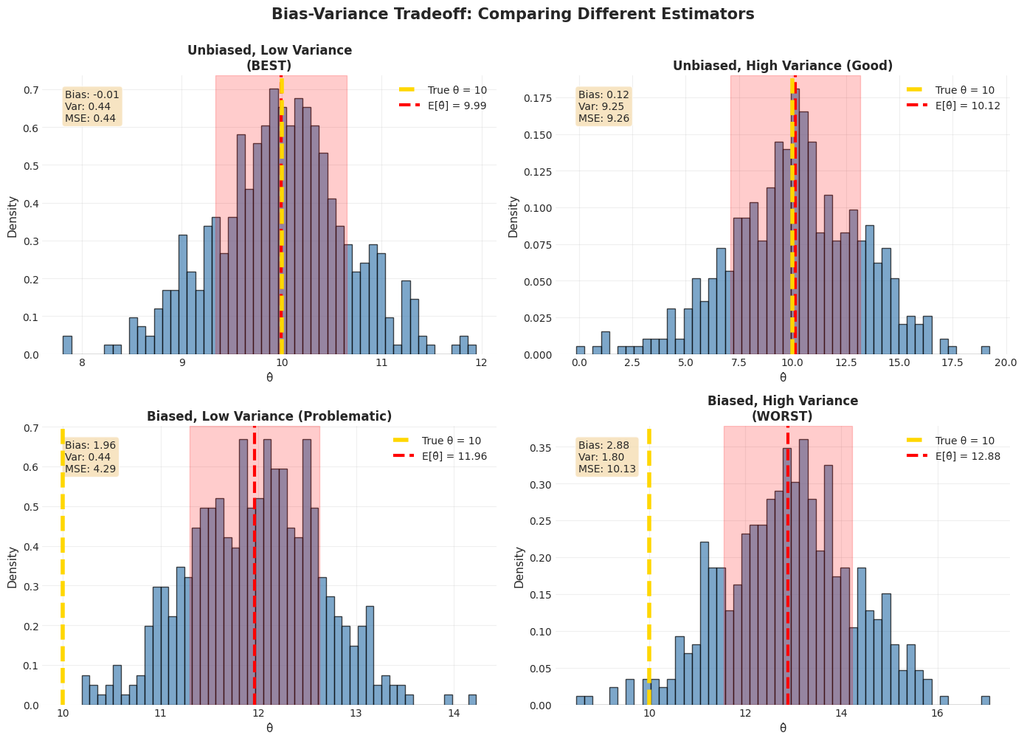

```
============================================================
BIAS-VARIANCE DECOMPOSITION: MSE = Bias² + Variance
============================================================

Unbiased, Low Variance
(BEST):
  Bias²     = 0.00
  Variance  = 0.44
  MSE       = 0.44
  Bias²+Var = 0.44

Unbiased, High Variance (Good):
  Bias²     = 0.02
  Variance  = 9.25
  MSE       = 9.26
  Bias²+Var = 9.26

Biased, Low Variance (Problematic):
  Bias²     = 3.85
  Variance  = 0.44
  MSE       = 4.29
  Bias²+Var = 4.29

Biased, High Variance
(WORST):
  Bias²     = 8.32
  Variance  = 1.80
  MSE       = 10.13
  Bias²+Var = 10.13
```

```python
# bias variance
visualize_bias_variance_tradeoff()
```

#### 💡 Key Insights: Bias and Variance

**Bias = Systematic error**

- Where is your dart cluster *centered*?
- Low bias: centered on target (bullseye)
- High bias: consistently off to one side

**Variance = Random error**

- How *spread out* are your darts?
- Low variance: tight cluster
- High variance: wide scatter

**The Goal**: Low bias AND low variance

- Hit the bullseye consistently
- This means: $E[\hat{\theta}] = \theta$ (unbiased) AND $Var(\hat{\theta})$ is small

**The Trade-off**: Sometimes we accept a little bias to get much lower variance

- Like a slightly off-center but very tight dart cluster
- This is the bias-variance trade-off in machine learning
- *Example*: Ridge regression accepts small bias for lower variance

#### 🤖 ML Application Spotlight: Bias-Variance in Model Selection

This is THE fundamental tradeoff in machine learning.

**Underfitting (High Bias)**:

- Model too simple
- Systematically misses patterns
- Low training AND test accuracy

**Overfitting (High Variance):**

- Model too complex
- Learns noise in training data
- High training accuracy, poor test accuracy

*Goal*: Find the sweet spot that minimizes MSE = Bias² + Variance

*Example*: Polynomial regression degree selection

- Degree 1: High bias (too simple)
- Degree 20: High variance (too complex)
- Degree 3-5: Just right for most problems

#### Question: Mini-Exercise on Estimator Properties

Given data from $N(\mu=10, \sigma^2=3^2)$, analyze the three estimators below: sample mean, sample mean of first half of the data + 5, and sample median.

**Tasks:**

1. Run 1000 experiments with n=50 samples each
2. For each estimator, calculate:
- Empirical bias
- Empirical variance
- Empirical MSE
3. Which estimator is best? Why?

```python
# Define estimators
def estimator_A(data):
    """Sample mean"""
    return np.mean(data)

def estimator_B(data):
    """Mean of first half + 5"""
    return np.mean(data[:len(data)//2]) + 5

def estimator_C(data):
    """Median"""
    return np.median(data)
```

```python
# ANSWER
def solution_mini_exercise_estimator_properties(true_mean = 10, true_std = 3, n = 50, n_trials = 1000):
    """
    Solution for mini-exercise: Comparing Three Estimators
    """

    # Setup
    np.random.seed(42)

    # Run simulation
    estimates_A, estimates_B, estimates_C = [], [], []

    for _ in range(n_trials):
        sample = np.random.normal(true_mean, true_std, n)
        estimates_A.append(estimator_A(sample))
        estimates_B.append(estimator_B(sample))
        estimates_C.append(estimator_C(sample))

    # Convert to arrays
    estimates_A = np.array(estimates_A)
    estimates_B = np.array(estimates_B)
    estimates_C = np.array(estimates_C)

    # Calculate metrics: Mean, Bias, Variance, MSE
    results = {}
    for name, estimates in [('A (Mean)', estimates_A),
                           ('B (Mean of Half+5)', estimates_B),
                           ('C (Median)', estimates_C)]:
        mean_est = np.mean(estimates)
        bias = mean_est - true_mean
        variance = np.var(estimates, ddof=1)
        mse = np.mean((estimates - true_mean)**2)

        results[name] = {
            'mean': mean_est,
            'bias': bias,
            'variance': variance,
            'mse': mse
        }

    # Display results
    print(f"True parameter: μ = {true_mean}")
    print(f"Sample size: n = {n}")
    print(f"Number of trials: {n_trials}")
    print()
    print(f"{'Estimator':<20s} {'E[θ̂]':<10s} {'Bias':<10s} {'Variance':<10s} {'MSE':<10s}")

    for name, res in results.items():
        print(f"{name:<20s} {res['mean']:>9.4f} {res['bias']:>9.4f} {res['variance']:>9.4f} {res['mse']:>9.4f}")

    print()
    print("VERIFICATION: MSE = Bias² + Variance")
    for name, res in results.items():
        calc_mse = res['bias']**2 + res['variance']
        print(f"{name:<20s}: {res['bias']**2:.4f} + {res['variance']:.4f} = {calc_mse:.4f}")

    return estimates_A, estimates_B, estimates_C, results
```

```python
# ANSWER
estimates_A, estimates_B, estimates_C, results = solution_mini_exercise_estimator_properties()
```

```
True parameter: μ = 10
Sample size: n = 50
Number of trials: 1000

Estimator            E[θ̂]      Bias       Variance   MSE
A (Mean)                9.9987   -0.0013    0.1860    0.1858
B (Mean of Half+5)     15.0025    5.0025    0.3961   25.4208
C (Median)              9.9973   -0.0027    0.2783    0.2780

VERIFICATION: MSE = Bias² + Variance
A (Mean)            : 0.0000 + 0.1860 = 0.1860
B (Mean of Half+5)  : 25.0251 + 0.3961 = 25.4212
C (Median)          : 0.0000 + 0.2783 = 0.2783
```

COMMENTS:

1. Estimator A (Mean): BEST
- Unbiased (bias ≈ 0)
- Lowest variance
- Lowest MSE
2. Estimator B (Mean of Half+5): WORST
- Heavily biased (bias = +5)
- High MSE due to bias²
- Never use a biased estimator without good reason
3. Estimator C (Median): OKAYISH
- Unbiased (for symmetric distributions)
- Higher variance than mean
- Better than mean when outliers are present

| When to use Median | When to use Mean |
| --- | --- |
| Data has outliers (robust to extreme values) | No significant outliers |
| Skewed distributions (median = 'typical' value) Heavy-tailed distributions When a few extreme values shouldn't influence result | Data is (approximately) normally distributed |
|  | Want most efficient estimator (lowest variance) |
|  | Need to use established statistical tests (t-test, etc.) |

Let's explore the case with outliers.

```python
true_mean = 10
true_std = 3
n = 50
n_trials = 1000

# Generate data with outliers
n_outlier_experiments = 1000
sample_size_outlier = 50
contamination_rate = 0.1  # 10% outliers

estimates_mean_outlier = []
estimates_median_outlier = []

for _ in range(n_outlier_experiments):
    # Generate mostly normal data
    sample = np.random.normal(true_mean, true_std, sample_size_outlier)

    # Add some outliers
    n_outliers = int(contamination_rate * sample_size_outlier)
    outlier_indices = np.random.choice(sample_size_outlier, n_outliers, replace=False)
    sample[outlier_indices] = np.random.uniform(30, 50, n_outliers)  # Extreme values

    estimates_mean_outlier.append(np.mean(sample))
    estimates_median_outlier.append(np.median(sample))

estimates_mean_outlier = np.array(estimates_mean_outlier)
estimates_median_outlier = np.array(estimates_median_outlier)

# Calculate MSE with outliers
mse_mean_outlier = np.mean((estimates_mean_outlier - true_mean)**2)
mse_median_outlier = np.mean((estimates_median_outlier - true_mean)**2)

print(f"With {contamination_rate:.0%} outliers:")
print(f"  MSE (Mean):   {mse_mean_outlier:.4f}")
print(f"  MSE (Median): {mse_median_outlier:.4f}")

if mse_median_outlier < mse_mean_outlier:
    print("Median WINS! It's robust to outliers.")
    print(f"Median reduces MSE by {(1 - mse_median_outlier/mse_mean_outlier)*100:.1f}%")
```

```
With 10% outliers:
  MSE (Mean):   9.2953
  MSE (Median): 0.4810
Median WINS! It's robust to outliers.
Median reduces MSE by 94.8%
```

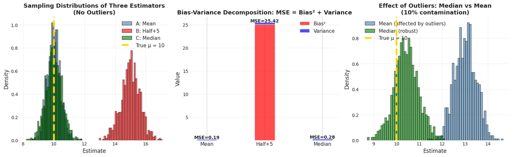

```python
# visualisation
fig, axes = plt.subplots(ncols=3, figsize=(16, 5))

# Plot 1: Distributions of all three estimators
ax = axes[0]

ax.hist(estimates_A, bins=40, alpha=0.6, color='steelblue',
       edgecolor='black', density=True, label='A: Mean')
ax.hist(estimates_B, bins=40, alpha=0.6, color='red',
       edgecolor='black', density=True, label='B: Half+5')
ax.hist(estimates_C, bins=40, alpha=0.6, color='green',
       edgecolor='black', density=True, label='C: Median')

ax.axvline(true_mean, color='gold', linewidth=4, linestyle='--',
          label=f'True μ = {true_mean}', zorder=10)

ax.set_xlabel('Estimate', fontsize=12)
ax.set_ylabel('Density', fontsize=12)
ax.set_title('Sampling Distributions of Three Estimators\n(No Outliers)',
            fontsize=13, fontweight='bold')
ax.legend(fontsize=11)
ax.grid(True, alpha=0.3)

# Plot 2: Bias-Variance decomposition
ax = axes[1]

names = list(results.keys())
biases_sq = [results[name]['bias']**2 for name in names]
variances = [results[name]['variance'] for name in names]

x = np.arange(len(names))
width = 0.35

bars1 = ax.bar(x, biases_sq, width, label='Bias²', color='red', alpha=0.7)
bars2 = ax.bar(x, variances, width, bottom=biases_sq, label='Variance',
               color='blue', alpha=0.7)

# Add MSE values on top
for i, name in enumerate(names):
    mse = results[name]['mse']
    ax.text(i, mse + 0.1, f'MSE={mse:.2f}', ha='center', fontsize=10, fontweight='bold')

ax.set_ylabel('Value', fontsize=12)
ax.set_title('Bias-Variance Decomposition: MSE = Bias² + Variance',
            fontsize=13, fontweight='bold')
ax.set_xticks(x)
ax.set_xticklabels(['Mean', 'Half+5', 'Median'], fontsize=11)
ax.legend(fontsize=11)
ax.grid(True, alpha=0.3, axis='y')

# Plot 3: With outliers comparison
ax = axes[2]

ax.hist(estimates_mean_outlier, bins=40, alpha=0.6, color='steelblue',
       edgecolor='black', density=True, label='Mean (affected by outliers)')
ax.hist(estimates_median_outlier, bins=40, alpha=0.6, color='green',
       edgecolor='black', density=True, label='Median (robust)')

ax.axvline(true_mean, color='gold', linewidth=4, linestyle='--',
          label=f'True μ = {true_mean}', zorder=10)

ax.set_xlabel('Estimate', fontsize=12)
ax.set_ylabel('Density', fontsize=12)
ax.set_title('Effect of Outliers: Median vs Mean\n(10% contamination)',
            fontsize=13, fontweight='bold')
ax.legend(fontsize=11)
ax.grid(True, alpha=0.3)

plt.tight_layout()
plt.show()
```

### Is My Variance High?

> How to evaluate if variance is high?

Note that variance bu itself is just a number (e.g. $Var(\hat{\theta} = 0.1)$). To be able to assess if its value is high or low, we need more information, e.g.:

- If $\theta \approx 1000$, then variance of 0.1 is tiny (very precise)
- If $\theta \approx 0.01$, then variance of 0.1 is huge (very imprecise)
1. **Method 1: Coefficient of Variation**

The most common approach is to compare variance to the magnitude of what is estimated.

#### Definition: Coefficient of Variation

**Coefficient of Variation** (CV) is a standardized measure of dispersion of a probability distribution or frequency distribution. It is defined as the ratio of the standard deviation $\sigma$ to the mean $\mu$ (or its absolute value, $|\mu |$). It shows the extent of variability in relation to the mean of the population.

$$CV(X) = \frac{\sigma}{\mu} = \frac{\sqrt{Var(X)}}{|E[X]|}$$

**Interpretation**:

- CV < 0.1 (10%): Low variance, very precise
- CV ≈ 0.1 - 0.3 (10-30%): Moderate variance, acceptable
- CV > 0.3 (30%): High variance, imprecise
- CV > 1 (100%): Very high variance, unreliable

```python
# coefficient of variation
estimates = np.array([98, 102, 95, 103, 97, 101])
mean_estimate = np.mean(estimates)  # 99.33
std_estimate = np.std(estimates, ddof=1)  # 3.08

CV = std_estimate / mean_estimate
print(f"CV = {CV:.3f} = {CV*100:.1f}%")
```

```
CV = 0.032 = 3.2%
```

2. **Method 2: Relative to Bias (MSE Context)**

**Question**: Is variance large compared to bias?

**Rule**:

- If Variance >> Bias²: High variance problem (need more data)
- If Bias² >> Variance: High bias problem (need better model)
- If Bias² ≈ Variance: Balanced

```python
# example
true_param = 10
estimates = np.array([15.1, 15.3, 14.9, 15.2, 15.0])

mean_est = np.mean(estimates)  # 15.1
bias = mean_est - true_param   # 5.1
variance = np.var(estimates, ddof=1)  # 0.02

print(f"Bias² = {bias**2:.3f}")      # 26.01
print(f"Variance = {variance:.3f}")  # 0.02

if variance < bias**2:
    print("Bias² >> Variance → HIGH BIAS problem")
    print("Variance is actually LOW relative to bias")
elif variance > bias**2:
    print("Bias² << Variance → HIGH VARIANCE problem (need more data)")
```

```
Bias² = 26.010
Variance = 0.025
Bias² >> Variance → HIGH BIAS problem
Variance is actually LOW relative to bias
```

3. **Method 3: Relative to Sample Size**

**Expected behavior**: Var(θ̂) should decrease as n increases

For most estimators: $$Var(\hat{\theta}) \propto 1/n$$

**If variance doesn't decrease with n**: Something is wrong!

```python
# example
# Simulate variance at different sample sizes
sample_sizes = [10, 50, 100, 500, 1000]
variances = []

for n in sample_sizes:
    estimates = []
    for _ in range(1000):
        sample = np.random.normal(10, 3, n)
        estimates.append(np.mean(sample))
    variances.append(np.var(estimates))

# Check if variance decreases as 1/n
for n, var in zip(sample_sizes, variances):
    print(f"n={n:4d}: Var={var:.4f}, n×Var={n*var:.2f}")
```

```
n=  10: Var=0.8705, n×Var=8.71
n=  50: Var=0.1803, n×Var=9.02
n= 100: Var=0.0918, n×Var=9.18
n= 500: Var=0.0192, n×Var=9.58
n=1000: Var=0.0084, n×Var=8.40
```

4. **Method 4: Relative to Other Estimators (Efficiency)**

**Relative Efficiency**: Compare variance of two estimators for same parameter

$$\text{Efficiency of } \hat{\theta}_1 \text{ relative to } \hat{\theta}_2 = Var(\hat{\theta}_2) / Var(\hat{\theta}_1)$$

```python
# example
# Compare mean vs median for normal data
n_trials = 1000
n = 50

estimates_mean = []
estimates_median = []

for _ in range(n_trials):
    sample = np.random.normal(10, 3, n)
    estimates_mean.append(np.mean(sample))
    estimates_median.append(np.median(sample))

var_mean = np.var(estimates_mean, ddof=1)
var_median = np.var(estimates_median, ddof=1)

efficiency = var_median / var_mean
print(f"Var(mean) = {var_mean:.4f}")
print(f"Var(median) = {var_median:.4f}")
print(f"Efficiency = {efficiency:.2f}")
```

```
Var(mean) = 0.1746
Var(median) = 0.2755
Efficiency = 1.58
```

In the example above, median ($\hat{\theta}_2$) has 57% MORE variance than mean. Hence, mean ($\hat{\theta}_1$) has "lower" variance (more efficient).

5. **Method 5: Confidence Interval Width**

**Practical perspective**: Is the uncertainty acceptable for your application?

**95% Confidence Interval**: $\hat{\theta} \pm 1.96 \times \sqrt{Var(\hat{\theta})}$

$$Width = 2 \times 1.96 \times \sqrt{Var(\hat{\theta})} \approx 4 \times SD(\hat{\theta})$$

Note that depending on the application domain, the same value may be acceptable or not.

```python
# example
# Estimating model accuracy
mean_accuracy = 0.85
std_accuracy = 0.05

# 95% CI
ci_lower = mean_accuracy - 1.96 * std_accuracy
ci_upper = mean_accuracy + 1.96 * std_accuracy
ci_width = ci_upper - ci_lower

print(f"Accuracy: {mean_accuracy:.2f} ± {1.96*std_accuracy:.2f}")
print(f"95% CI: [{ci_lower:.2f}, {ci_upper:.2f}]")
print(f"CI width: {ci_width:.2f}")
```

```
Accuracy: 0.85 ± 0.10
95% CI: [0.75, 0.95]
CI width: 0.20
```

In the example above, the width is 20% which is NOT acceptable for critical medical application (too wide) but can be acceptable for exploratory analysis.

**Rules of thumb for CI width**:

- Width < 0.1: Low variance (precise)
- Width 0.1 - 0.3: Moderate variance (acceptable)
- Width > 0.3: High variance (imprecise)
6. **Method 6: Domain Knowledge**

**Context matters**: What's acceptable depends on your problem.

|  |  | Scenario 1 | Scenario 2 |
| --- | --- | --- | --- |
| **ML Model Accuracy** | **Domain** | **Medical diagnosis** | **Movie recommendation** |
|  | **Accuracy** | 0.90 ± 0.10 | 0.70 ± 0.10 |
|  | **CI** | [0.80, 1.00] | [0.60, 0.80] |
|  | **Assessment** | HIGH VARIANCE (unacceptable) | Moderate variance (acceptable) |
|  | **Why?** | 80% vs 90% is a huge difference in medicine | Small accuracy variations are OK here |
| **Parameter Estimation** | **Domain** | **Bridge engineering** | **Marketing campaign reach** |
|  | **Parameter** | Estimated load capacity | Estimated viewers |
|  | **Value** | 1000 tons ± 200 tons | 1M ± 200K |
|  | **CV** | 20% | 20% |
|  | **Assessment** | HIGH VARIANCE (unacceptable) | Low variance (acceptable) |
|  | **Why?** | Safety critical, need precision | Rough estimates are sufficient |

#### 💡 Key Insights: Variance Assessment: Decision Framework

**Step 1**: Calculate $CV = SD(\hat{\theta}) / |E[\hat{\theta}]|$

- CV < 10%: Low variance
- CV 10-30%: Moderate variance
- CV > 30%: High variance

**Step 2**: Check MSE decomposition

- If Variance >> Bias²: Variance is the problem
- If Bias² >> Variance: Bias is the problem

**Step 3**: Compare to other estimators

- Is there a lower-variance alternative?
- What's the efficiency loss?

**Step 4**: Consider practical implications

- Is the CI width acceptable?
- Does it meet your application requirements?

**Step 5**: Use domain knowledge

- What precision does your problem actually need?
- What are the consequences of uncertainty?

## Parameter Estimation Task

#### Problem Statement: Parameter Estimation Task

Our observed data: $X_1, X_2, ..., X_n$

We believe they come from a distribution with parameter $\theta$ (e.g., $N(θ, 1)$)

**Question**: Which value of $\theta$ makes our observed data "most likely"?

## Method of Moments (MoM)

#### Definition: Methods of Moments (MoM)

**Match sample moments to population moments**, then solve for parameters.

**Population moments**: $E[X]$, $E[X^2]$, $E[X^3]$, ... (depend on unknown parameters $\theta$)

**Sample moments**: $\bar{X}$, $(1/n)\sum_{i=1}^n X_i^2$, $(1/n)\sum_i{i=1}^n X_i^3$, ... (computed from data)

**Method**: Set sample moments equal to population moments, solve for $\theta$.

##### Algorithm

For a distribution with $k$ parameters $\theta = (\theta_1, ..., \theta_k)$:

1. Write first $k$ population moments in terms of $\theta$:
   - $\mu_1 = E[X] = g_1(\theta)$
   - $\mu_2 = E[X^2] = g_2(\theta)$
   - ...
   - $\mu_k = E[X^k] = g_k(\theta)$
2. Compute corresponding sample moments:
   - $m_1 = \bar{X} = (1/n)\sum_i^n X_i$
   - $m_2 = (1/n)\sum_{i=1}^n X_i^2$
   - ...
   - $m_k = (1/n)\sum_{i=1}^n X_i^k$
3. Solve the system of equations:
   - $m_1 = g_1(\hat{\theta})$
   - $m_2 = g_2(\hat{\theta})$
   - ...
   - $m_k = g_k(\hat{\theta})$

#### Calculated Example: MoM for Normal Distribution, N(μ, σ²) Normal distribution $\mathcal{N}(\mu, \sigma^2)$ has two parameters $\mu, \sigma^2$ → need two moments **Population moments:** $E[X] = \mu$ $E[X²] = \sigma^2 + \mu^2$ **Sample moments:** $m_1 = \bar{X}$ $m_2 = (1/n)\sum_{i=1}^n X_i^2$ **Method of Moments equations:** $\hat{\mu} = \bar{X}$ $\hat{\sigma}^2 + \hat{\mu}^2 = (1/n)\sum_{i=1}^n X_i^2$ **Solving:** $\hat{\mu}_{MoM} = \bar{X}$ $\hat{\sigma}^2_{MoM} = (1/n)\sum_{i=1}^n X_i^2 - \bar{X}^2 = (1/n)\sum_{i=1}^n(X_i - \bar{X})^2$ **Note**: This gives the *biased* variance estimator (divides by $n$, not $n-1$)

#### Calculated Example: MoM for Exponential Distribution, Exp(λ)

One parameter ($\lambda$) → need one moment

**Population moment:**

- $E[X] = 1/\lambda$

**Sample moment:**

- $m_1 = \bar{X}$

**Method of Moments equation:**

- $1/\hat{\lambda} = \bar{X}$

**Solving:**

- $\hat{\lambda}_{MoM} = 1/\bar{X}$

When to Use Method of Moments

**Advantages:**

- Simple to compute (just solve equations)
- No optimization needed
- Good starting values for numerical MLE
- Works when MLE is intractable

**Disadvantages:**

- Less efficient than MLE
- May give biased estimates
- Ignores likelihood structure
- Can give invalid estimates (e.g., negative variance)

**Practical use:**

- Quick initial estimates
- Starting point for iterative MLE
- When MLE is computationally expensive
- Sanity check for MLE results

Let $X_1, X_2, ..., X_n$ be independent realisations of r.v. $X$ with $\mathbb{E}X = \mu$ and $Var(X) = \sigma^2$.

We define the moment estimators as follows: $$\begin{array}{l}\hat{\mu} = \bar{X}\\\hat{\sigma}^2 = s^2\end{array}$$

> Is there quality satisfactory?

**Part I: Quality of the estimator** $\hat{\mu} = \bar{X}$

1. Let's calculate bias of the estimator $\hat{\mu} = \bar{X}$

$$Bias(\hat{\theta},\theta) = \mathbb{E}[\hat{\theta}] − \theta = Bias(\hat{\mu}, \mu) = \mathbb{E}[\hat{\mu}] − \mu = $$

$$= \mathbb{E}[\bar{X}] − \mu = \mathbb{E}\bigg[1/n \sum_{𝑖=1}^n X_i\bigg] − \mu = [\text{by propr. of E,} E[aX + b] = 𝑎E[X] + b] = 1/n \mathbb{E}[\sum_{i=1}^n X_i] − \mu $$

$$= [\text{by propr. of E,} E[X + Y] = E[X] + E[Y]] = 1/n \sum_{i=1}^n E[X_i] − \mu = 1/n n \mu − \mu = \mathbf{0}$$

So, the estimator $\hat{\mu} = \bar{X}$ is **unbiased**.

2. Let's calculate the variance of the estimator $\hat{\mu} = \bar{X}$

$$Var(\hat{\mu}) = Var(\bar{X}) = Var\bigg(1/n \sum_{i=1}^n X_i\bigg) = [\text{by propr. of Var, } Var(aX + b) = a^2Var(X)] = \frac{1}{n^2}Var\bigg(\sum_{i=1}^n X_i\bigg) = $$ $$= [\text{by propr. of Var of indep. X and Y, } Var(X + Y) = Var(X) + Var(Y)] = \frac{1}{n^2}\sum_{i=1}^n Var(X_i) = \frac{1}{n^2}n\sigma^2 = \frac{\sigma^2}{n} \xrightarrow[n\rightarrow \infty]{} 0$$

3. Calculate MSE of the estimator $\hat{\mu} = \bar{X}$

$$MSE(\hat{\mu}, \mu) = Bias(\hat{\mu}, \mu)^2 + Var(\hat{\mu}) = \frac{\sigma^2}{n} \xrightarrow[n\rightarrow \infty]{} 0$$

So, it is a convergent estimator in the mean square sense.

**Part II: Quality of the estimator** $\hat{\sigma}^2 = s^2$

1. Let's calculate bias of the estimator $\hat{\sigma}^2 = s^2$

$$Bias(\hat{\theta},\theta) = \mathbb{E}[\hat{\theta}] − \theta = Bias(\hat{\sigma}^2, \sigma^2) = \mathbb{E}[\hat{\sigma}^2] − \sigma^2 = \mathbb{E}[s^2] − \sigma^2 =$$ $$= \mathbb{E}\bigg[\frac{1}{n}\sum_{i=1}^n(X_i^2 - \bar{X})\bigg] - \sigma^2 = \bigg[\text{by propr. of E, } E[X + Y] = EX + EY\bigg] = \mathbb{E}\bigg[\frac{1}{n}\sum_{i=1}^nX_i^2\bigg] - \mathbb{E}[\bar{X}^2] - \sigma^2 = $$

$$\bigg[\text{by propr. of E, } E[aX + b] = aEX + b\bigg] = \frac{1}{n}\mathbb{E}\bigg[\sum_{i=1}^nX_i^2\bigg] - \mathbb{E}[\bar{X}^2] - \sigma^2 =$$

$$\bigg[\text{by propr. of E, } E[X + Y] = EX + EY\bigg] = \frac{1}{n}\sum_{i=1}^n\mathbb{E}[X_i^2] - \mathbb{E}[\bar{X}^2] - \sigma^2 = \frac{1}{n}n\mathbb{E}[X^2] - \mathbb{\hat{\mu}^2} - \sigma^2 =$$

$$= \mathbb{E}[X^2] - \mathbb{\hat{\mu}^2} - \sigma^2 = \bigg[\text{by def. } Var(X) = E[X^2] - (EX)^2 \Rightarrow E[X^2] = Var(X) + (EX)^2\bigg] = $$

$$= (Var(X) + (EX)^2) - (Var(\hat{\mu}) + (\mathbb{E}[\hat{\mu}])^2) - \sigma^2 = (\sigma^2 + \mu^2) - \bigg(\frac{\sigma^2}{n} + \mu^2\bigg) - \sigma^2 =$$

$$= \bigg(1 - \frac{1}{n}\bigg)\sigma^2 - \sigma^2 = -\frac{\sigma^2}{n} \mathbf{\neq 0}$$

So, the estimator $\hat{\sigma}^2 = s^2$ is **biased**.

To make it *unbiased*, we can apply so called **Bessel's correction**:

$$\hat{\sigma}'^2 = s'^2 = \frac{n}{n-1}s^2$$

#### Definition: Bessel's Correction

Unbiased estimator of variance is given by:

$$\hat{\sigma}'^2 = \frac{1}{n-1}\sum_{i=1}^n(X_i - \bar{X})^2$$

*Note:* we divide by $(n-1)$ instead of $n$ here.

## Maximum Likelihood Estimator (MLE)

Imagine you flip a coin 10 times and get HTHHHTHHHH:

[figure not shown]

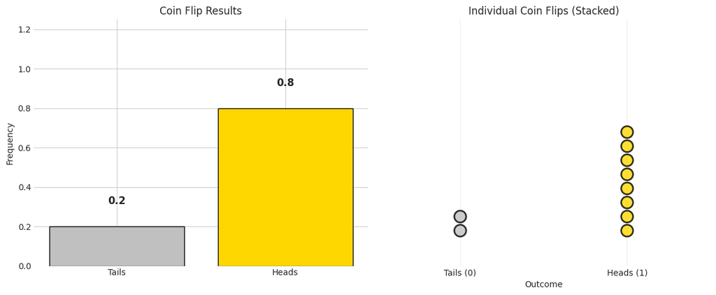

```python
# visualisation
plot_heads_tails()
```

Our goal is to find the optimal way to fit a distribution to the data in order to facilitate the work and generalise the observations.

In a more general way, we think the data follows Binomial distribution with parameter $p$ of having a head in a single coin flip. The probability mass function is given by $P(X=k | n, p) = \begin{pmatrix}n \\ k\end{pmatrix}p^k q^{n-k} = \frac{n!}{k!(n-k)!}p^k q^{n-k}$ and for $n=10$ it looks something like that:

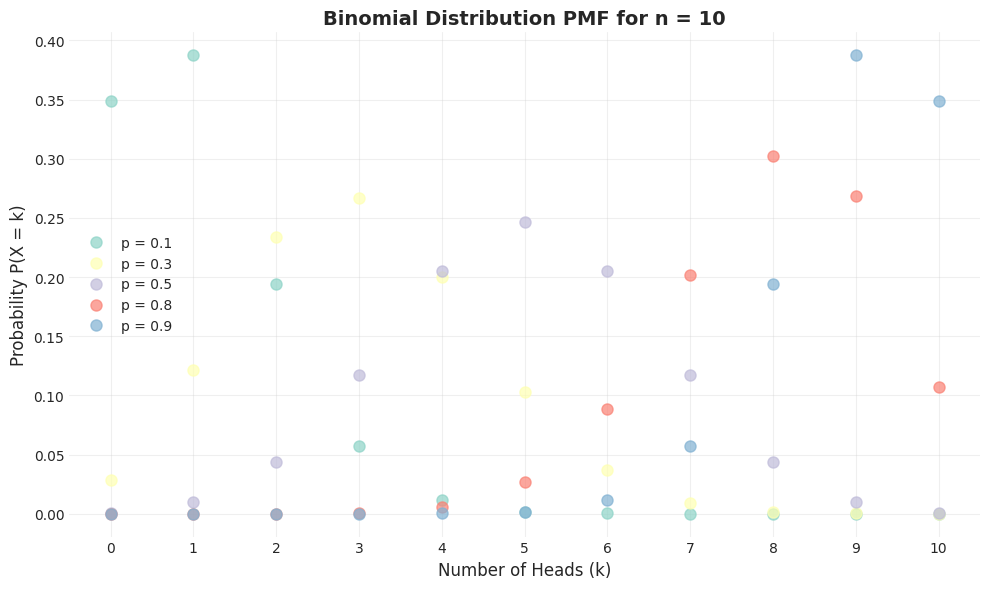

```python
# visualise binomial distribution mass function for n=10
plot_binomial()
```

For instance, the probability that we get 8 heads out of 10 flips of a fair coin is: $$P(X=8 | n=10, p=0.5) = \frac{10!}{8!(10-8)!}0.5^8 0.5^{10-8} = \frac{10!}{8!2!}0.5^8 0.5^{2} = \frac{9\times 10}{2}\frac{1}{2^{10}} = 9 \times 5 \times \frac{1}{2^{10}} \approx 0.044$$

So our question is then:

> Which value of $p$ makes our observed data most probable?

If we want to calculate the likelihood of $p = 0.5$, then we need to rearrange our equation by **modifying only the left side**:

$$L(p=0.5 | n=10, X=8) = \frac{10!}{8!(10-8)!}0.5^8 0.5^{10-8} = \frac{10!}{8!2!}0.5^8 0.5^{2} = \frac{9\times 10}{2}\frac{1}{2^{10}} = 9 \times 5 \times \frac{1}{2^{10}} \approx 0.044$$

The left side of the equation reads "*the likelihood of $p$ (the probability to get a head), given $n$, the number of flips we make, and $X$, the number of heads*".

**Note** that we can modify the values of $p$ in this equation, but the observed data ($n=10$ and $X=8$) remains fixed:

$$L(p=0.3 | n=10, X=8) = \frac{10!}{8!(10-8)!}0.3^8 0.7^{10-8} = \frac{10!}{8!2!}0.3^8 0.7^{2} = \frac{9\times 10}{2}\times 0.00007\times 0.49 = 9 \times 5 \times 0.00007\times 0.49 \approx 0.00145$$

$$L(p=0.8 | n=10, X=8) = \frac{10!}{8!(10-8)!}0.8^8 0.2^{10-8} = \frac{10!}{8!2!}0.8^8 0.2^{2} \approx 0.302$$

```
Observed data: 8 heads in 10 flips
H T H H H T H H H H

Numerical MLE: 0.8019
Analytical MLE: 0.8000
They match (as they should)
```

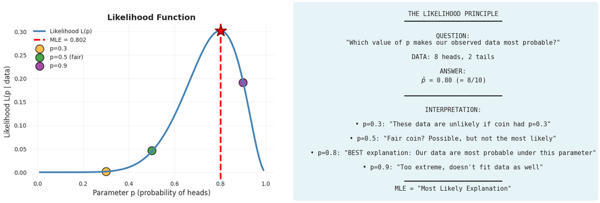

```python
demonstrate_likelihood_concept()
```

#### Reminder: Joint Probability of Independent R.V.

> How likely is all the data together?

We need to use **joint probability**.

Let $X_1, X_2, ..., X_n$ be i.i.d.

Recall that two events $A$ and $B$ are *independent* if:

$$P(A\cap B) = P(A)\times P(B)$$

For our data, independence means:

- Observing $X_1$ doesn't affect $X_2$
- Each data point is drawn separately from the same distribution
- Knowing one observation tells us nothing about another

For *discrete variables*, the joint probability of independent r.v. is expressed as a product of individual probabilities: $$P(X_1=x_1, X_2=x_2, …, X_n=x_n∣\theta) = \prod_{i=1}^n P(X_i=x_i∣\theta)$$

For *continuous variables*, the joint probability of independent r.v. is expressed as a product of probability density functions (PDFs): $$f(x_1, x_2, \ldots, x_n | \theta) = \prod_{i=1}^{n} f(x_i | \theta)$$

*Example*: Suppose you flip a fair coin 3 times and get: H, H, T with $P(H)=0.5$ for each flip. Flips are independent (one doesn't affect another).

Joint probability: $P(H, H, T) = P(H)\times P(H)\times P(T) = 0.5\times 0.5 \times 0.5 = 0.125$

**What if Data Aren't Independent?** If observations are not independent (e.g., time series, spatial data, grouped data):

- We cannot write likelihood as a simple product
- Need more complex joint distributions
- This is why independence assumption is so important!

*Example*: Time series

- Today's stock price depends on yesterday's
- Need to model $P(X_t | X_{t-1}, X_{t-2}, \ldots)$
- Likelihood is more complex

#### Definition: Maximum Likelihood Estimation

Setup:

- Data: $X_1, X_2, ..., X_n \sim f(x | \theta)$ (i.i.d. from distribution with parameter $\theta$)
- Goal: Estimate $\theta$

**Likelihood Function**, "*probability of observing the data, as a function of $\theta$*": $$L(\theta | X) = \prod_{i=1}^{n} f(X_i | \theta)$$

**Log-Likelihood:** $$\ell(\theta | X) = \log L(\theta | X) = \sum_{i=1}^{n} \log f(X_i | \theta)$$ (Taking log: easier to work with, doesn't change location of maximum)

**Maximum Likelihood Estimator:**

$$\hat{\theta}_{MLE} = \arg\max_{\theta} L(\theta | X) = \arg\max_{\theta} \ell(\theta | X)$$

How to find it:

1. Write down likelihood (or log-likelihood)
2. Take derivative with respect to $\theta$
3. Set equal to zero and solve
4. Verify it's a maximum (second derivative test)

### MLE for Bernoulli Distribution

#### Worked Example: MLE for Bernoulli Distribution

**Scenario: Email Spam Rate Estimation**

You're building a spam classifier. From your training data, you observe:

- $n = 1000$ emails
- $k = 230$ are spam

**Question**: Estimate $p$ = probability that a random email is spam using MLE

Model: Each email is spam with probability $p$ (Bernoulli distribution)

```python
# Observed data
np.random.seed(42)
n = 1000
k = 230
observed_data = np.array([1]*k + [0]*(n-k))  # 1=spam, 0=ham
np.random.shuffle(observed_data)

print(f"Data (10 first observations): {observed_data[:10]}")
```

```
Data (10 first observations): [0 0 0 0 0 0 0 0 0 1]
```

1. **Step 1: Write the Likelihood Function**

Each email $X_i \sim Bernoulli(p)$. Therefore, $\begin{array}{ll} P(X_i = 1) = p & \text{(spam)} \\ P(X_i = 0) = 1-p & \text{(not spam)}\end{array}$

$$L(p|X) = \prod_i^n P(X_i| p) = \prod_i^n p^{X_i} \times (1-p)^{(1-X_i)} = [k = \text{\# of successes}, n = \text{\# trials}] = p^k\times (1-p)^{(n-k)}$$

```python
# for our data
print("L(p) = ∏ᵢ P(Xᵢ | p)")
print("     = ∏ᵢ p^Xᵢ (1-p)^(1-Xᵢ)")
print(f"     = p^{k} (1-p)^{n-k}")
```

```
L(p) = ∏ᵢ P(Xᵢ | p)
     = ∏ᵢ p^Xᵢ (1-p)^(1-Xᵢ)
     = p^230 (1-p)^770
```

2. **Step 2: Write the Log-Likelihood Function**

$$l(p|X) = \log L(p|X) = \log (p^k\times (1-p)^{n-k}) = \log (p^k) + \log (1-p)^{n-k} = k \log (p) + (n-k) \log(1-p)$$

```python
# for our data
print("ℓ(p) = log L(p)")
print(f"     = {k} log(p) + {n-k} log(1-p)")
```

```
ℓ(p) = log L(p)
     = 230 log(p) + 770 log(1-p)
```

3. **Step 3: Take the Derivative**

$$\frac{dl}{dp} = \frac{d}{dp}(k\log(p) + (n-k)\log(1-p)) = k\times\frac{1}{p} - (n-k)\frac{1}{1-p} = \frac{k}{p} - \frac{n-k}{1-p}$$

```python
# for our data
print(f"dℓ/dp = {k}/p - {n-k}/(1-p)")
```

```
dℓ/dp = 230/p - 770/(1-p)
```

4. **Step 4: Set Derivative to 0 and Solve**

$$\frac{dl}{dp} = 0$$

$$\frac{k}{p} - \frac{n-k}{1-p} = 0$$

$$\frac{k}{p} = \frac{n-k}{1-p}$$

$$k\times (1-p) = (n-k)p$$

$$k - kp = np - kp$$

$$k = np + kp - kp$$

$$k = np$$

$$p = \frac{k}{n}$$

**Step 5: Verify It's a Maximum**

Check second derivative:

$$\frac{d^2\mathcal{l}}{dp^2} = \frac{d}{dp}\bigg(\frac{k}{p} - \frac{n-k}{1-p}\bigg) = -\frac{k}{p^2} - \frac{n-k}{(1-p)^2}$$

At $\hat{p} = \frac{k}{n}$, $$\frac{d^2\mathcal{l}}{dp^2}\bigg|_{(p = k/n)} = - \frac{k}{(k/n)^2} - \frac{n-k}{(1-k/n)^2} =$$ $$= - \frac{kn^2}{k^2} - \frac{(n-k)n^2}{(n-k)^2} = - \frac{n^2}{k} - \frac{n^2}{(n-k)} = - n^2\bigg(\frac{1}{k} + \frac{1}{n-k}\bigg) < 0$$

Second derivative is NEGATIVE → this is a MAXIMUM.

```python
p_mle = k / n
# Calculate each term
term1 = -k / (p_mle**2)
term2 = -(n-k) / ((1-p_mle)**2)
second_deriv = term1 + term2
print(f"d²ℓ/dp²|_(p={p_mle}) = {term1:.4f} + {term2:.4f} = {second_deriv:.4f}")
alt_form = -n**2 * (1/k + 1/(n-k))
print(f"")
print(f"d²ℓ/dp²|_(p={k}/{n}) = -{n}² × [1/{k} + 1/{(n-k)}]")
print(f"  = -{n**2} × [{1/k:.4f} + {1/(n-k):.4f}]")
print(f"  = {alt_form:.4f}")
```

```
d²ℓ/dp²|_(p=0.23) = -4347.8261 + -1298.7013 = -5646.5274

d²ℓ/dp²|_(p=230/1000) = -1000² × [1/230 + 1/770]
  = -1000000 × [0.0043 + 0.0013]
  = -5646.5274
```

6. **Step 6: Compute the MLE**

Intuitive result: MLE = observed proportion

```python
p_mle = k / n
print(f"MLE = {p_mle:.2f}")
```

```
MLE = 0.23
```

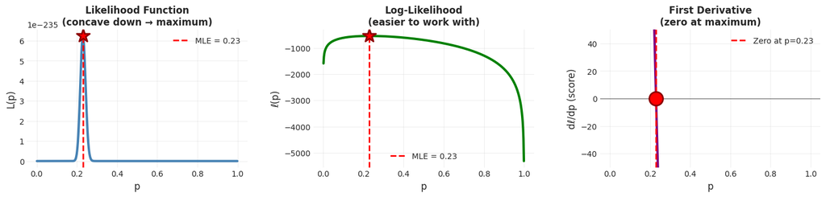

```python
n_tails = n - k
n_heads = k
# Visualization
fig = plt.figure(figsize=(18, 12))
gs = fig.add_gridspec(3, 3, hspace=0.4, wspace=0.3)

p_range = np.linspace(0.001, 0.999, 500)

# Plot 1: Likelihood
ax1 = fig.add_subplot(gs[0, 0])
likelihood = p_range**n_heads * (1-p_range)**n_tails
ax1.plot(p_range, likelihood, linewidth=3, color='steelblue')
ax1.axvline(p_mle, color='red', linewidth=2, linestyle='--',
           label=f'MLE = {p_mle:.2f}')
ax1.scatter(p_mle, p_mle**n_heads * (1-p_mle)**n_tails, s=300,
           color='red', marker='*', edgecolors='darkred', linewidths=2, zorder=5)
ax1.set_xlabel('p', fontsize=12)
ax1.set_ylabel('L(p)', fontsize=12)
ax1.set_title('Likelihood Function\n(concave down → maximum)',
             fontsize=12, fontweight='bold')
ax1.legend(fontsize=10)
ax1.grid(True, alpha=0.3)

# Plot 2: Log-likelihood
ax2 = fig.add_subplot(gs[0, 1])
log_likelihood = n_heads * np.log(p_range) + n_tails * np.log(1-p_range)
ax2.plot(p_range, log_likelihood, linewidth=3, color='green')
ax2.axvline(p_mle, color='red', linewidth=2, linestyle='--',
           label=f'MLE = {p_mle:.2f}')
ax2.scatter(p_mle, n_heads * np.log(p_mle) + n_tails * np.log(1-p_mle),
           s=300, color='red', marker='*', edgecolors='darkred', linewidths=2, zorder=5)
ax2.set_xlabel('p', fontsize=12)
ax2.set_ylabel('ℓ(p)', fontsize=12)
ax2.set_title('Log-Likelihood\n(easier to work with)',
             fontsize=12, fontweight='bold')
ax2.legend(fontsize=10)
ax2.grid(True, alpha=0.3)

# Plot 3: First derivative (score)
ax3 = fig.add_subplot(gs[0, 2])
first_deriv = n_heads / p_range - n_tails / (1 - p_range)
ax3.plot(p_range, first_deriv, linewidth=3, color='purple')
ax3.axhline(0, color='black', linewidth=1, linestyle='-', alpha=0.5)
ax3.axvline(p_mle, color='red', linewidth=2, linestyle='--',
           label=f'Zero at p={p_mle:.2f}')
ax3.scatter(p_mle, 0, s=300, color='red', marker='o',
           edgecolors='darkred', linewidths=2, zorder=5)
ax3.set_xlabel('p', fontsize=12)
ax3.set_ylabel("dℓ/dp (score)", fontsize=12)
ax3.set_title('First Derivative\n(zero at maximum)',
             fontsize=12, fontweight='bold')
ax3.legend(fontsize=10)
ax3.grid(True, alpha=0.3)
ax3.set_ylim(-50, 50)


plt.tight_layout()
plt.show()
```

#### 🤖 ML Application: Logistic Regression Loss Function

**Connection:** The MLE for Bernoulli is exactly what logistic regression does.

Logistic regression loss (binary cross-entropy): $$\mathcal{L} = -\sum_{i=1}^{n} [y_i \log(\hat{p}_i) + (1-y_i) \log(1-\hat{p}_i)]$$

This is the **negative log-likelihood** for Bernoulli data.

**Training a logistic regression = Finding MLE of the parameters**

### MLE for Exponential Distribution

#### Worked Example: MLE for Exponential Distribution

**Scenario: Server Response Times**

You're analyzing server response times (in seconds). Theory suggests response times follow an Exponential distribution.

Recall, $Exponential(\lambda)$ has:

- PDF: $f(x|\lambda) = \lambda e^{-\lambda x}$ for $x \geq 0$
- Mean: $1/\lambda$
- Interpretation: $\lambda$ = rate parameter (events per unit time)

Observed data: response times for 20 requests

**Question:** find $\hat{\lambda}$ using MLE.

```python
# Generate example data
np.random.seed(42)
true_lambda = 0.5  # True rate (unknown in practice)
n = 20
data = np.random.exponential(1/true_lambda, n)

print(f"Data (first 10 out of {n} observations): {data[:10]}")
# Summary statistics
print(f"Sample mean: {np.mean(data):.3f} seconds")
print(f"Sample min:  {np.min(data):.3f} seconds")
print(f"Sample max:  {np.max(data):.3f} seconds")
```

```
Data (first 10 out of 20 observations): [0.93853618 6.02024286 2.63349139 1.82588511 0.33924974 0.33919258
 0.11967754 4.02246173 1.83816431 2.46250012]
Sample mean: 1.824 seconds
Sample min:  0.042 seconds
Sample max:  7.007 seconds
```

1. **Step 1: Write the Likelihood Function**

For i.i.d. data $X_1, X_2, ..., X_n \sim Exponential(\lambda)$:

$$L(\lambda | X) = \prod_{i=1}^n f(X_i | \lambda) = \prod_{i=1}^n \lambda e^{-\lambda X_i} = \lambda^n \prod_{i=1}^n e^{-\lambda X_i} = [\text{by prop. of exp. func., } e^a\times e^b = e^{a+b}] = \lambda^n e^{-\sum_{i=1}^n \lambda X_i} = \lambda^n e^{- \lambda \sum_{i=1}^n X_i}$$

```python
# likelihood for our data
sum_X_i = np.sum(data)
print(f"∑Xᵢ = {sum_X_i:.3f}")
print(f"L(λ) = λ^{n} × exp(-λ × {np.sum(data):.3f})")
```

```
∑Xᵢ = 36.478
L(λ) = λ^20 × exp(-λ × 36.478)
```

2. **Step 2: Take the Log-Likelihood**

$$\mathcal{l}(\lambda|X) = \log L(\lambda|X) = \log (\lambda^n e^{- \lambda \sum_{i=1}^n X_i}) = [\text{by propr. of log}] = \log(\lambda^n) + \log(e^{- \lambda \sum_{i=1}^n X_i}) =$$

$$= n\log(\lambda) + (- \lambda \sum_{i=1}^n X_i) = n\log(\lambda) - \lambda \sum_{i=1}^n X_i$$

```python
# for our data
print(f"ℓ(λ) = {n} log(λ) - λ × {np.sum(data):.3f}")
```

```
ℓ(λ) = 20 log(λ) - λ × 36.478
```

3. **Step 3: Take the Derivative**

$$\frac{d\mathcal{l}}{d\lambda} = \frac{d}{d\lambda}\bigg(n\log(\lambda) - \lambda \sum_{i=1}^n X_i\bigg) = n\frac{1}{\lambda} - \sum_{i=1}^n X_i = \frac{n}{\lambda} - \sum_{i=1}^n X_i$$

```python
# for our data
print(f"dℓ/dλ = {n}/λ - {np.sum(data):.3f}")
```

```
dℓ/dλ = 20/λ - 36.478
```

4. **Step 4: Set Derivative to 0 and Solve**

$$\frac{d\mathcal{l}}{d\lambda} = 0$$

$$\frac{n}{\lambda} - \sum_{i=1}^n X_i = 0$$

$$\frac{n}{\lambda} = \sum_{i=1}^n X_i$$

$$\lambda = \frac{n}{\sum_{i=1}^n X_i}$$

Note that $\bar{X} = 1/n\sum_{i=1}^n X_i$, so:

$$\hat{\lambda}_{MLE} = \frac{1}{\bar{X}}$$

So, MLE for Exponential rate = 1 / sample mean.

5. **Step 5: Verify It's a Maximum**

Check second derivative:

$$\frac{d^2\mathcal{l}}{d\lambda^2} = \frac{d}{d\lambda}\bigg(\frac{n}{\lambda} - \sum_{i=1}^n X_i\bigg) = -\frac{n}{\lambda^2}$$

Since $n > 0$ and $\lambda^2 > 0$: $\frac{d^2\mathcal{l}}{d\lambda^2} = -\frac{n}{\lambda^2} < 0$

Second derivative is NEGATIVE → this is a MAXIMUM.

6. **Step 6: Compute the MLE**

```python
# compute MLE for our data
sample_mean = np.mean(data)
mle_lambda = 1 / sample_mean
print(f"Sample mean: X̄ = {sample_mean:.4f}")
print(f"λ̂_MLE = 1 / X̄ = 1 / {sample_mean:.4f} = {mle_lambda:.4f}")

print()
print(f"True λ (unknown in practice): {true_lambda:.4f}")
print(f"Error: {abs(mle_lambda - true_lambda):.4f}")
```

```
Sample mean: X̄ = 1.8239
λ̂_MLE = 1 / X̄ = 1 / 1.8239 = 0.5483

True λ (unknown in practice): 0.5000
Error: 0.0483
```

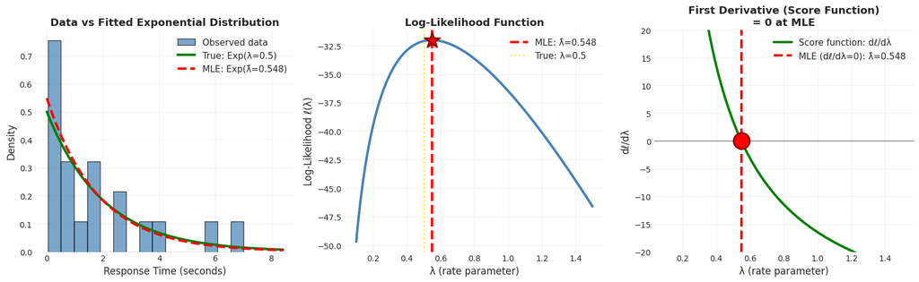

```python
# Visualization
fig, axes = plt.subplots(ncols=3, figsize=(16, 5))

# Plot 1: Data histogram with fitted distribution
ax = axes[0]

ax.hist(data, bins=15, density=True, alpha=0.7, color='steelblue',
           edgecolor='black', label='Observed data')

x_range = np.linspace(0, np.max(data)*1.2, 200)

# True distribution
ax.plot(x_range, true_lambda * np.exp(-true_lambda * x_range),
           'g-', linewidth=3, label=f'True: Exp(λ={true_lambda})')

# MLE distribution
ax.plot(x_range, mle_lambda * np.exp(-mle_lambda * x_range),
           'r--', linewidth=3, label=f'MLE: Exp(λ̂={mle_lambda:.3f})')

ax.set_xlabel('Response Time (seconds)', fontsize=12)
ax.set_ylabel('Density', fontsize=12)
ax.set_title('Data vs Fitted Exponential Distribution',
                fontsize=13, fontweight='bold')
ax.legend(fontsize=11)
ax.grid(True, alpha=0.3)

# Plot 2: Log-likelihood function
ax = axes[1]

lambda_range = np.linspace(0.1, 1.5, 200)
log_likelihoods = []

for lam in lambda_range:
    ll = n * np.log(lam) - lam * np.sum(data)
    log_likelihoods.append(ll)

log_likelihoods = np.array(log_likelihoods)

ax.plot(lambda_range, log_likelihoods, linewidth=3, color='steelblue')
ax.axvline(mle_lambda, color='red', linewidth=3, linestyle='--',
              label=f'MLE: λ̂={mle_lambda:.3f}')
ax.scatter(mle_lambda, n * np.log(mle_lambda) - mle_lambda * np.sum(data),
              s=400, color='red', marker='*', edgecolors='darkred',
              linewidths=2, zorder=5)

ax.axvline(true_lambda, color='gold', linewidth=2, linestyle=':',
              label=f'True: λ={true_lambda}', alpha=0.7)

ax.set_xlabel('λ (rate parameter)', fontsize=12)
ax.set_ylabel('Log-Likelihood ℓ(λ)', fontsize=12)
ax.set_title('Log-Likelihood Function', fontsize=13, fontweight='bold')
ax.legend(fontsize=11)
ax.grid(True, alpha=0.3)

# Plot 3: Derivative (score function)
ax = axes[2]

derivatives = n / lambda_range - np.sum(data)

ax.plot(lambda_range, derivatives, linewidth=3, color='green',
           label='Score function: dℓ/dλ')
ax.axhline(0, color='black', linewidth=1, linestyle='-', alpha=0.5)
ax.axvline(mle_lambda, color='red', linewidth=3, linestyle='--',
              label=f'MLE (dℓ/dλ=0): λ̂={mle_lambda:.3f}')
ax.scatter(mle_lambda, 0, s=400, color='red', marker='o',
              edgecolors='darkred', linewidths=2, zorder=5)

ax.set_xlabel('λ (rate parameter)', fontsize=12)
ax.set_ylabel('dℓ/dλ', fontsize=12)
ax.set_title('First Derivative (Score Function)\n= 0 at MLE',
                fontsize=13, fontweight='bold')
ax.legend(fontsize=11)
ax.grid(True, alpha=0.3)
ax.set_ylim(-20, 20)

plt.tight_layout()
plt.show()
```

#### 💡 Key Insights: MLE for Exponential Distribution

1. For Exponential: MLE = 1 / sample mean
2. $\lambda$ is RATE (events per time) and $1/\lambda$ is MEAN TIME between events
3. If $\bar{X} = 2$ seconds → $\hat{\lambda} = 0.5$ per second (one event every 2 seconds on average)

#### 🤖 ML APPLICATION: Time-to-Event Modeling

Exponential distribution is used in ML for:

1. Waiting times:
- Time between user clicks
- Server request intervals
- Time to next purchase
2. Survival Analysis:
- Customer churn modeling
- Time to equipment failure
- Session duration
3. Deep Learning:
- Dropout regularization (exponential draws)
- Exponential learning rate decay

*Example*: If $\hat{\lambda} = 0.5$ requests/second:

- Average wait: 1/0.5 = 2 seconds
- $P(wait > 5 sec) = exp(-0.5 × 5) \approx 8.2\%$
- Useful for capacity planning

### MLE for Normal Distribution

#### Worked Example: MLE for Normal Distribution

Find the MLE for both parameters of Normal distribution $N(\mu, \sigma^2)$.

```python
# Generate sample data
np.random.seed(42)
true_mu = 5
true_sigma = 2
n = 100
data = np.random.normal(true_mu, true_sigma, n)

print(f"Data (10 first observations): {data[:10]}")
```

```
Data (10 first observations): [5.99342831 4.7234714  6.29537708 8.04605971 4.53169325 4.53172609
 8.15842563 6.53486946 4.06105123 6.08512009]
```

1. **Step 1: Write the Likelihood Function**

$$L(\mu, \sigma^2|X) = \prod_{i=1}^n \frac{1}{\sqrt{2\pi\sigma^2}} exp(-(X_i-\mu)^2/(2\sigma^2)) = (\frac{1}{\sqrt{2\pi}})^n\prod_{i=1}^n \frac{1}{\sqrt{\sigma^2}} exp(-(X_i-\mu)^2/(2\sigma^2)) =$$ $$= (2\pi)^{-n/2}\prod_{i=1}^n \frac{1}{\sqrt{\sigma^2}} exp(-(X_i-\mu)^2/(2\sigma^2)) = (2\pi)^{-n/2} (\frac{1}{\sqrt{\sigma^2}})^n\prod_{i=1}^n exp(-(X_i-\mu)^2/(2\sigma^2)) ==$$ $$=(2\pi)^{-n/2} (\sigma^2)^{-n/2}\prod_{i=1}^n exp(-(X_i-\mu)^2/(2\sigma^2))$$

2. **Step 2: Write the Log-Likelihood**

$$\ell(\mu, \sigma^2|X) = \log L(\mu, \sigma^2|X) = \log \bigg((2\pi)^{-n/2} (\sigma^2)^{-n/2}\prod_{i=1}^n exp(-(X_i-\mu)^2/(2\sigma^2))\bigg) =$$ $$= \log((2\pi)^{-n/2}) + \log((\sigma^2)^{-n/2}) + \log\bigg(\prod_{i=1}^n exp(-(X_i-\mu)^2/(2\sigma^2))\bigg) = -n/2 \log(2\pi) - n/2 \log(\sigma^2) + \log(exp(-\sum_{i=1}^n((X_i-\mu)^2/(2\sigma^2)))) =$$ $$= -n/2 \log(2\pi) - n/2 \log(\sigma^2) + \log(exp(-1/(2\sigma^2)\sum_{i=1}^n(X_i-\mu)^2)) =$$ $$= -n/2 \log(2\pi) - n/2 \log(\sigma^2) - 1/(2\sigma^2) \sum_{i=1}^n(X_i-\mu)^2$$

3. **Step 3: Take Derivatives**

$$\frac{\partial l}{\partial\mu} = \frac{\partial }{\partial\mu} \bigg(-n/2 \log(2\pi) - n/2 \log(\sigma^2) - 1/(2\sigma^2) \sum_{i=1}^n(X_i-\mu)^2\bigg) = \frac{\partial }{\partial\mu} \bigg(- 1/(2\sigma^2) \sum_{i=1}^n(X_i-\mu)^2\bigg) =$$ $$=- 1/(2\sigma^2)\times(-1)\times 2\times \sum_{i=1}^n(X_i-\mu) = 1/\sigma^2 \sum_{i=1}^n(X_i-\mu)$$

$$\frac{\partial l}{\partial\sigma^2} = \frac{\partial }{\partial\sigma^2} \bigg(-n/2 \log(2\pi) - n/2 \log(\sigma^2) - 1/(2\sigma^2) \sum_{i=1}^n(X_i-\mu)^2\bigg) = -n/2\times 1/\sigma^2 + 1/(2\sigma^4) \sum_{i=1}^n(X_i-\mu)^2 = -n/(2\sigma^2) + 1/(2\sigma^4) \sum_{i=1}^n(X_i-\mu)^2$$

4. **Step 4: Set Derivatives to 0 and Solve**
5. for $\mu$ $$\frac{\partial l}{\partial\mu} = 1/\sigma^2 \sum_{i=1}^n(X_i-\mu) = 0$$ $$\sum_{i=1}^n(X_i-\mu) = 0$$ $$\sum_{i=1}^nX_i - n\mu = 0$$ $$\mu = 1/n\sum_{i=1}^nX_i$$

Note that we get *sample mean*.

2. for $\sigma^2$ $$\frac{\partial l}{\partial\sigma^2} = -n/(2\sigma^2) + 1/(2\sigma^4) \sum_{i=1}^n(X_i-\mu)^2 = 0$$ $$-n/(2\sigma^2) + 1/(2\sigma^4) \sum_{i=1}^n(X_i-\mu)^2 = 0$$ $$-n + 1/(\sigma^2)\sum_{i=1}^n(X_i-\mu)^2 = 0$$ $$1/(\sigma^2)\sum_{i=1}^n(X_i-\mu)^2 = n$$ $$\sum_{i=1}^n(X_i-\mu)^2 = n\sigma^2$$ $$1/n\sum_{i=1}^n(X_i-\mu)^2 = \sigma^2$$

Note that we get *sample variance* (biased).

5. **Step 5: Verify These Are Maximum**

Since we have two parameters, we need to compute the Hessian matrix: $$H = \begin{pmatrix} \frac{\partial^2 \ell}{\partial \mu^2} & \frac{\partial^2 \ell}{\partial \mu \partial \sigma^2} \ \frac{\partial^2 \ell}{\partial \sigma^2 \partial \mu} & \frac{\partial^2 \ell}{\partial (\sigma^2)^2} \end{pmatrix}$$

For a maximum, we need the Hessian to be negative definite at the MLE.

Computing Each Second Derivative

1. Second derivative with respect to $\mu$ $$\frac{\partial^2 \ell}{\partial \mu^2} = \frac{\partial}{\partial \mu}\left[\frac{n}{\sigma^2}(\bar{X} - \mu)\right]$$ $$= \frac{n}{\sigma^2} \times (-1) = -\frac{n}{\sigma^2}$$

*Note*: This doesn't depend on $\mu$. It's constant.

2. Second derivative with respect to $\sigma^2$ $$\frac{\partial^2 \ell}{\partial (\sigma^2)^2} = \frac{\partial}{\partial \sigma^2}\left[-\frac{n}{2\sigma^2} + \frac{1}{2\sigma^4}\sum_{i=1}^{n}(X_i - \mu)^2\right]$$

For the first term:

$$\frac{\partial}{\partial \sigma^2}\left[-\frac{n}{2\sigma^2}\right] = -\frac{n}{2} \times \frac{\partial}{\partial \sigma^2}[(\sigma^2)^{-1}] = -\frac{n}{2} \times (-1)(\sigma^2)^{-2} = \frac{n}{2\sigma^4}$$

For the second term:

$$\frac{\partial}{\partial \sigma^2}\left[\frac{1}{2\sigma^4}\sum_{i=1}^{n}(X_i - \mu)^2\right] = \frac{1}{2}\sum_{i=1}^{n}(X_i - \mu)^2 \times (-2)(\sigma^2)^{-3} = -\frac{\sum_{i=1}^{n}(X_i - \mu)^2}{\sigma^6}$$

Combining:

$$\frac{\partial^2 \ell}{\partial (\sigma^2)^2} = \frac{n}{2\sigma^4} - \frac{\sum_{i=1}^{n}(X_i - \mu)^2}{\sigma^6}$$

3. Cross partial derivative $$\frac{\partial^2 \ell}{\partial \mu \partial \sigma^2} = \frac{\partial}{\partial \sigma^2}\left[\frac{n}{\sigma^2}(\bar{X} - \mu)\right]$$ $$= n(\bar{X} - \mu) \times \frac{\partial}{\partial \sigma^2}[(\sigma^2)^{-1}]=$$ $$= n(\bar{X} - \mu) \times (-1)(\sigma^2)^{-2} = -\frac{n(\bar{X} - \mu)}{\sigma^4}$$

Evaluating at the MLE

At the MLE: $\hat{\mu} = \bar{X}$ and $\hat{\sigma}^2 = \frac{1}{n}\sum_{i=1}^{n}(X_i - \bar{X})^2$

1. At $\hat{\mu}, \hat{\sigma}^2$: $$\frac{\partial^2 \ell}{\partial \mu^2}\bigg|_{\hat{\mu}, \hat{\sigma}^2} = -\frac{n}{\hat{\sigma}^2} < 0 \quad ✓$$

*Interpretation*: Always negative → concave down in $\mu$ direction

2. At $\hat{\mu}, \hat{\sigma}^2$: $$\frac{\partial^2 \ell}{\partial (\sigma^2)^2}\bigg|_{\hat{\mu}, \hat{\sigma}^2} = \frac{n}{2\hat{\sigma}^4} - \frac{\sum_{i=1}^{n}(X_i - \bar{X})^2}{\hat{\sigma}^6}$$

Substitute $\hat{\sigma}^2 = \frac{1}{n}\sum_{i=1}^{n}(X_i - \bar{X})^2$:

$$= \frac{n}{2\hat{\sigma}^4} - \frac{n\hat{\sigma}^2}{\hat{\sigma}^6} = \frac{n}{2\hat{\sigma}^4} - \frac{n}{\hat{\sigma}^4} = -\frac{n}{2\hat{\sigma}^4} < 0 \quad ✓$$

*Interpretation*: Negative at the MLE → concave down in $\sigma^2$ direction

3. Cross partial at $\hat{\mu}, \hat{\sigma}^2$: $$\frac{\partial^2 \ell}{\partial \mu \partial \sigma^2}\bigg|_{\hat{\mu}, \hat{\sigma}^2} = -\frac{n(\bar{X} - \hat{\mu})}{\hat{\sigma}^4}$$

Since $\hat{\mu} = \bar{X}$:

$$= -\frac{n \times 0}{\hat{\sigma}^4} = 0$$

*Interpretation*: No interaction between $\mu$ and $\sigma^2²$ at the MLE (parameters are orthogonal)

The Hessian Matrix at MLE $$H\bigg|_{\hat{\mu}, \hat{\sigma}^2} = \begin{pmatrix} -\frac{n}{\hat{\sigma}^2} & 0 \ 0 & -\frac{n}{2\hat{\sigma}^4} \end{pmatrix}$$

This is a diagonal matrix with both diagonal entries negative!

*Verifying Negative Definiteness*

For a matrix to be negative definite, we need:

- All eigenvalues negative, OR
- Leading principal minors alternate in sign (starting negative)

*Method 1: Eigenvalues*:

Since $H$ is diagonal, eigenvalues are just the diagonal entries:

- $\lambda_1 = -\frac{n}{\hat{\sigma}^2} < 0 ✓$
- $\lambda_2 = -\frac{n}{2\hat{\sigma}^4} < 0 ✓$

Both negative → negative definite ✓

*Method 2: Principal Minors*

First leading principal minor:

$$M_1 = -\frac{n}{\hat{\sigma}^2} < 0 \quad ✓$$

Second leading principal minor (determinant):

$$M_2 = \det(H) = \left(-\frac{n}{\hat{\sigma}^2}\right) \times \left(-\frac{n}{2\hat{\sigma}^4}\right) - 0^2 = \frac{n^2}{2\hat{\sigma}^6} > 0 \quad ✓$$

Signs alternate: (−, +) → negative definite ✓

Conclusion

1. Both diagonal entries of Hessian are negative
2. Off-diagonal entries are zero (parameters uncorrelated at MLE)
3. Hessian is negative definite
4. Therefore: $(\hat{\mu}, \hat{\sigma}^2) = (\bar{X}, \frac{1}{n}\sum(X_i - \bar{X})^2)$ is a MAXIMUM
6. **Step 6: Compute MLE**

```python
# Analytical MLEs
mle_mu = np.mean(data)
mle_sigma = np.std(data, ddof=0)  # ddof=0 for MLE (biased estimator)

print(f"μ̂_MLE = {mle_mu:.4f}  (true: {true_mu})")
print(f"σ̂_MLE = {mle_sigma:.4f}  (true: {true_sigma})")
```

```
μ̂_MLE = 4.7923  (true: 5)
σ̂_MLE = 1.8072  (true: 2)
```

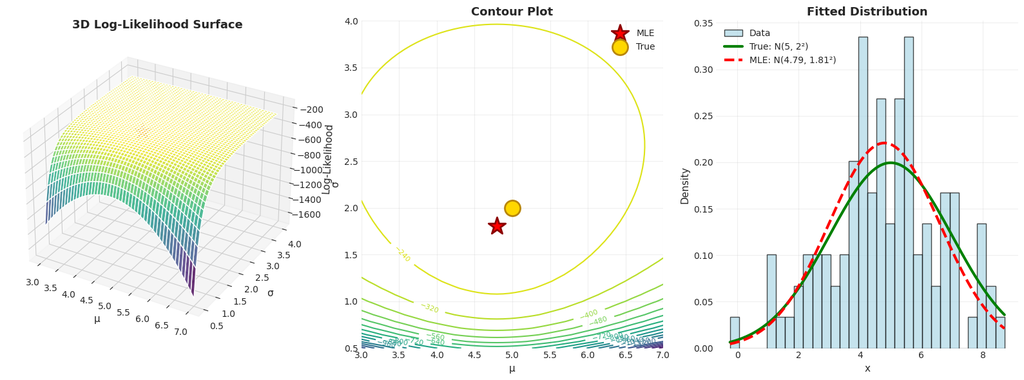

```python
# Visualization: 3D likelihood surface
fig = plt.figure(figsize=(16, 6))

# Create grid for parameters
mu_range = np.linspace(true_mu - 2, true_mu + 2, 50)
sigma_range = np.linspace(0.5, 4, 50)
MU, SIGMA = np.meshgrid(mu_range, sigma_range)

# Compute log-likelihood for each combination
log_likelihood = np.zeros_like(MU)
for i in range(len(mu_range)):
    for j in range(len(sigma_range)):
        mu = MU[j, i]
        sigma = SIGMA[j, i]
        ll = -n/2 * np.log(2*np.pi*sigma**2) - np.sum((data - mu)**2) / (2*sigma**2)
        log_likelihood[j, i] = ll

# Plot 1: 3D surface
ax1 = fig.add_subplot(131, projection='3d')
surf = ax1.plot_surface(MU, SIGMA, log_likelihood, cmap='viridis', alpha=0.8)
ax1.scatter([mle_mu], [mle_sigma], [np.max(log_likelihood)],
           color='red', s=300, marker='*', edgecolors='darkred', linewidths=2)
ax1.set_xlabel('μ', fontsize=11)
ax1.set_ylabel('σ', fontsize=11)
ax1.set_zlabel('Log-Likelihood', fontsize=11)
ax1.set_title('3D Log-Likelihood Surface', fontsize=13, fontweight='bold')

# Plot 2: Contour plot
ax2 = fig.add_subplot(132)
contour = ax2.contour(MU, SIGMA, log_likelihood, levels=20, cmap='viridis')
ax2.clabel(contour, inline=True, fontsize=8)
ax2.scatter(mle_mu, mle_sigma, s=400, color='red', marker='*',
           edgecolors='darkred', linewidths=2, label='MLE', zorder=5)
ax2.scatter(true_mu, true_sigma, s=300, color='gold', marker='o',
           edgecolors='darkgoldenrod', linewidths=2, label='True', zorder=5)
ax2.set_xlabel('μ', fontsize=11)
ax2.set_ylabel('σ', fontsize=11)
ax2.set_title('Contour Plot', fontsize=13, fontweight='bold')
ax2.legend()
ax2.grid(True, alpha=0.3)

# Plot 3: Fitted distribution
ax3 = fig.add_subplot(133)
ax3.hist(data, bins=30, density=True, alpha=0.7, color='lightblue',
        edgecolor='black', label='Data')

# True distribution
x_range = np.linspace(data.min(), data.max(), 200)
ax3.plot(x_range, stats.norm.pdf(x_range, true_mu, true_sigma),
        'g-', linewidth=3, label=f'True: N({true_mu}, {true_sigma}²)')

# MLE distribution
ax3.plot(x_range, stats.norm.pdf(x_range, mle_mu, mle_sigma),
        'r--', linewidth=3, label=f'MLE: N({mle_mu:.2f}, {mle_sigma:.2f}²)')

ax3.set_xlabel('x', fontsize=11)
ax3.set_ylabel('Density', fontsize=11)
ax3.set_title('Fitted Distribution', fontsize=13, fontweight='bold')
ax3.legend()
ax3.grid(True, alpha=0.3)

plt.tight_layout()
plt.show()
```

#### 💡 Key Insight: MLE vs. Unbiased Estimator

**Important note:** For normal distribution variance:

- MLE: $\sigma^2_MLE = (1/n) \sum_{i=1}^n(X_i - \hat{\mu})^2$ → **Biased** (underestimates on average)
- Unbiased: $s^2 = 1/(n-1) \sum_{i=1}^n(X_i - \hat{\mu})^2$ → **Unbiased**

**Why the difference?**

- MLE uses $\hat{\mu$ (estimated mean), not true $\mu$
- This introduces dependency, causing bias
- Factor $(n-1)$ corrects for this (Bessel's correction)

**In practice:** For large $n$, the difference is negligible!

### MLE Properties and Computation

#### Properties of MLE

**Asymptotic Properties** (as n → ∞):

1. **Consistency:** θ̂_MLE → θ (converges to true value)
2. **Asymptotic Normality:** $$\sqrt{n}(\hat{\theta}_{MLE} - \theta) \xrightarrow{d} N(0, I(\theta)^{-1})$$ where $I(\theta)$ is the Fisher Information
3. **Efficiency:** Among all consistent estimators, MLE has minimum asymptotic variance
4. **Invariance:** If $\hat{\theta}_{MLE}$ is MLE for $\theta$, then $g(\hat{\theta}_{MLE})$ is MLE for $g(\theta)$

**Why MLE is popular:**

- Strong theoretical properties
- Often has closed-form solution
- Intuitive interpretation
- Works well in practice

#### 🤖 ML Application: MLE via Optimization

When no closed-form solution exists, we use numerical optimization:

**Algorithm:** Gradient Ascent on Log-Likelihood

```
1. Initialize θ₀
2. Repeat:
   θₜ₊₁ = θₜ + α ∇ℓ(θₜ)
   where ∇ℓ(θ) = gradient of log-likelihood
3. Until convergence
```

This is exactly how we train ML models

- Neural networks: gradient descent on negative log-likelihood
- Logistic regression: same thing
- Many other models: MLE via optimization

## MoM vs MLE: Comparison

| Aspect | Method of Moments | Maximum Likelihood |
| --- | --- | --- |
| **Idea** | Match moments | Maximize probability of data |
| **Complexity** | Usually simpler | Can be complex |
| **Efficiency** | Less efficient | Most efficient (asymptotically) |
| **Existence** | Always exists | May not have closed form |
| **Optimality** | Not optimal | Optimal (under regularity) |
| **Bias** | Often biased | Asymptotically unbiased |

## Maximum A Posteriori (MAP) Estimation

#### The Limitation of MLE

MLE says: "Which $\theta$ makes the data most likely?" But what if we have prior knowledge about $\theta$?

*Example:*

- You're estimating spam rate from 10 emails. You observe 9 spam, 1 ham.
- MLE: $\hat{p} = 0.9$ (90% spam rate)
- But: You know from experience that typical spam rate is ~20-30%

**Question**: Shouldn't we incorporate this knowledge?

**Answer**: Yes. Use MAP estimation

*Background*: Based on millions of emails, we know spam rate ≈ 25%

Let's consider two scenarios:

1. *Scenario 1: Small Sample*
- Observed: 9 spam in 10 emails
- MLE: 90% spam rate
- Problem: Seems too high. Small sample might be misleading.
- Better idea: Combine data with prior knowledge...
2. *Scenario 2: Large Sample*
- Observed: 250 spam in 1,000 emails
- MLE: 25% spam rate
- Prior: ~25% expected
- Assessment: Data is strong evidence, prior less important.

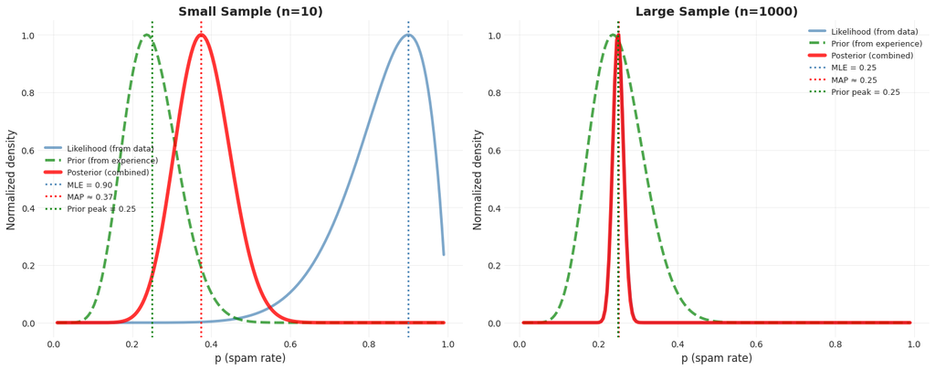

```python
# visualisation
demonstrate_prior_importance()
```

#### Definition: Maximum A Posteriori (MAP) Estimation

Bayes' Theorem: $$P(\theta | X) = \frac{P(X | \theta) P(\theta)}{P(X)} \propto P(X | \theta) P(\theta)$$

Where:

- $P(\theta|X)$ = posterior: probability of $\theta$ given data
- $P(X|\theta)$ = likelihood: probability of data given $\theta$
- $P(\theta)$ = prior: our belief about $\theta$ before seeing data
- $P(X)$ = evidence: normalizing constant (doesn't depend on $\theta$)

**MAP Estimator:**

$$\hat{\theta}_{MAP} = \arg\max_{\theta} P(\theta | X) = \arg\max_{\theta} [P(X | \theta) P(\theta)]$$

Or equivalently (taking logs):

$$\hat{\theta}_{MAP} = \arg\max_{\theta} [\log P(X | \theta) + \log P(\theta)] = \arg\max_{\theta} [\ell(\theta) + \log P(\theta)]$$

*Interpretation:*

- MLE: Maximize likelihood only
- MAP: Maximize likelihood + prior
- MAP incorporates prior knowledge

```
Data: 6 successes in 20 trials (true p = 0.3)

======================================================================
RESULTS:
======================================================================
MLE:              0.3000  (error: 0.0000)
MAP (weak prior): 0.2788  (error: 0.0212)
MAP (strong prior): 0.2820  (error: 0.0180)
True value:       0.3000
======================================================================
```

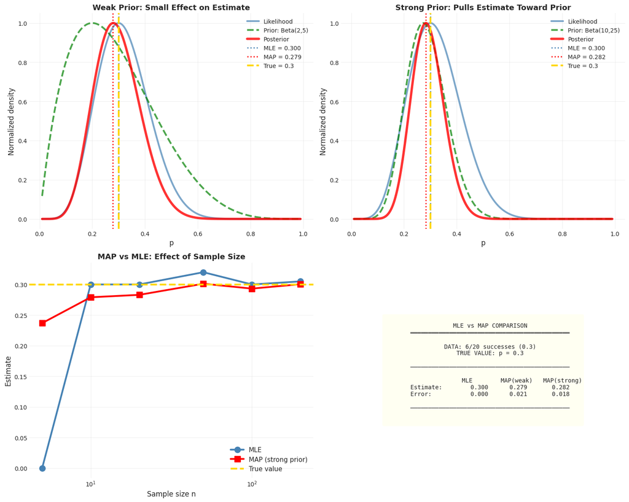

```python
# MLE vs MAP
compare_mle_map()
```

**Key Observation:** As $n \rightarrow \infty$, $MAP \rightarrow MLE$ (Data dominates prior with large samples)

| MLE | MAP |
| --- | --- |
| ✓ Uses only data ✗ Ignores prior knowledge | ✓ Incorporates prior knowledge |
| ✓ No assumptions beyond model | ✓ Regularizes estimates |
| ✗ Can overfit with small samples | ✓ Better with small samples |
|  | ✗ Requires choosing prior |

[output not shown]

#### 💡 Key Insight: When to Use MAP vs MLE?

Use MLE when:

- You have lots of data
- No strong prior knowledge
- Want purely data-driven estimates
- Interpretability is critical

Use MAP when:

- Limited data (prior helps regularize)
- Strong prior knowledge exists
- Want to incorporate domain expertise
- Overfitting is a concern

In practice: Many ML methods are actually MAP

#### 🤖 ML Connection: MAP = Regularization

**Regularization in ML is just MAP estimation with specific priors**

1. Ridge Regression (L2 regularization): $$\min_w ||y - Xw||^2 + \lambda||w||^2$$

This is equivalent to MAP with Gaussian prior on weights: $$\sim N(0, \sigma^2 I)$$ where $\lambda = 1/(2\sigma^2)$

2. Lasso Regression (L1 regularization): $$\min_w ||y - Xw||^2 + \lambda||w||_1$$ This is equivalent to MAP with Laplace prior on weights:

$$w \sim \text{Laplace}(0, b)$$

What this means:

- Regularization = imposing prior belief that weights should be small
- $\lambda$ = strength of prior belief
- Different regularizations = different prior distributions

#### ⚠️ Common Mistake: Forgetting to Normalize

**Problem:** Prior strength depends on data scale!

**Example:**

- Features in meters: λ=1 might be good
- Same features in millimeters: λ=1 is now way too weak!

**Solution:** Always normalize/standardize features before regularization:

```
from sklearn.preprocessing import StandardScaler
scaler = StandardScaler()
X_scaled = scaler.fit_transform(X)
```

This ensures regularization strength is interpretable and consistent

## Common Mistakes

#### ⚠️ Common Pitfalls

- Confusing estimate with true parameter
- Ignoring bias-variance tradeoff
- Forgetting to normalize before regularization
- Choosing wrong prior in MAP
- Not checking if solution is actually a maximum

## ML Applications

#### 🤖 ML Applications

- Model Training: All supervised learning is parameter estimation
- Regularization: L2/L1 penalties = Gaussian/Laplace priors
- Loss Functions: Cross-entropy = negative log-likelihood
- Optimization: Gradient descent = finding MLE/MAP

## Key Takeaways

#### 🎓 Key Takeaways

1. Point Estimation:
- Estimator = function that produces estimate from data
- Key properties: Bias, Variance, MSE
- MSE = Bias² + Variance (fundamental tradeoff)
2. Maximum Likelihood Estimation:
- Principle: Choose θ that makes data most likely
- Method: Maximize L(θ|X) or ℓ(θ|X)
- Properties: Consistent, efficient, asymptotically normal
- Computation: Closed-form or gradient ascent
3. Maximum A Posteriori:
- Principle: Maximize posterior = likelihood × prior
- Incorporates prior knowledge
- Connection: MAP with Gaussian prior = Ridge regression
- Becomes MLE as n → ∞

## Useful Links

1. [Maximum Likelihood, Clearly Explained!!! by StatQuest](https://www.youtube.com/watch?v=XepXtl9YKwc)
2. [In Statistics, Probability is not Likelihood by StatQuest](https://www.youtube.com/watch?v=pYxNSUDSFH4)
3. [Maximum Likelihood For the Normal Distribution, step-by-step!!! by StatQuest](https://www.youtube.com/watch?v=Dn6b9fCIUpM)
4. [Maximum Likelihood for the Exponential Distribution, Clearly Explained!! by StatQuest](https://www.youtube.com/watch?v=p3T-_LMrvBc)
5. [Maximum Likelihood for the Binomial Distribution, Clearly Explained!!! by StatQuest!!!](https://www.youtube.com/watch?v=4KKV9yZCoM4)
6. [What are degrees of freedom? by James Gilbert](https://www.youtube.com/watch?v=rATNoxKg1yA)